# 探索影响白葡萄酒质量的化学成分

```
##   X fixed.acidity volatile.acidity citric.acid residual.sugar chlorides
## 1 1           7.0             0.27        0.36           20.7     0.045
## 2 2           6.3             0.30        0.34            1.6     0.049
## 3 3           8.1             0.28        0.40            6.9     0.050
## 4 4           7.2             0.23        0.32            8.5     0.058
## 5 5           7.2             0.23        0.32            8.5     0.058
## 6 6           8.1             0.28        0.40            6.9     0.050
##   free.sulfur.dioxide total.sulfur.dioxide density   pH sulphates alcohol
## 1                  45                  170  1.0010 3.00      0.45     8.8
## 2                  14                  132  0.9940 3.30      0.49     9.5
## 3                  30                   97  0.9951 3.26      0.44    10.1
## 4                  47                  186  0.9956 3.19      0.40     9.9
## 5                  47                  186  0.9956 3.19      0.40     9.9
## 6                  30                   97  0.9951 3.26      0.44    10.1
##   quality
## 1       6
## 2       6
## 3       6
## 4       6
## 5       6
## 6       6
```

```
## 'data.frame':    4898 obs. of  13 variables:
##  $ X                   : int  1 2 3 4 5 6 7 8 9 10 ...
##  $ fixed.acidity       : num  7 6.3 8.1 7.2 7.2 8.1 6.2 7 6.3 8.1 ...
##  $ volatile.acidity    : num  0.27 0.3 0.28 0.23 0.23 0.28 0.32 0.27 0.3 0.22 ...
##  $ citric.acid         : num  0.36 0.34 0.4 0.32 0.32 0.4 0.16 0.36 0.34 0.43 ...
##  $ residual.sugar      : num  20.7 1.6 6.9 8.5 8.5 6.9 7 20.7 1.6 1.5 ...
##  $ chlorides           : num  0.045 0.049 0.05 0.058 0.058 0.05 0.045 0.045 0.049 0.044 ...
##  $ free.sulfur.dioxide : num  45 14 30 47 47 30 30 45 14 28 ...
##  $ total.sulfur.dioxide: num  170 132 97 186 186 97 136 170 132 129 ...
##  $ density             : num  1.001 0.994 0.995 0.996 0.996 ...
##  $ pH                  : num  3 3.3 3.26 3.19 3.19 3.26 3.18 3 3.3 3.22 ...
##  $ sulphates           : num  0.45 0.49 0.44 0.4 0.4 0.44 0.47 0.45 0.49 0.45 ...
##  $ alcohol             : num  8.8 9.5 10.1 9.9 9.9 10.1 9.6 8.8 9.5 11 ...
##  $ quality             : int  6 6 6 6 6 6 6 6 6 6 ...
```

```
##
##    3    4    5    6    7    8    9
##   20  163 1457 2198  880  175    5
```

```
##        X        fixed.acidity    volatile.acidity  citric.acid
##  Min.   :   1   Min.   : 3.800   Min.   :0.0800   Min.   :0.0000
##  1st Qu.:1225   1st Qu.: 6.300   1st Qu.:0.2100   1st Qu.:0.2700
##  Median :2450   Median : 6.800   Median :0.2600   Median :0.3200
##  Mean   :2450   Mean   : 6.855   Mean   :0.2782   Mean   :0.3342
##  3rd Qu.:3674   3rd Qu.: 7.300   3rd Qu.:0.3200   3rd Qu.:0.3900
##  Max.   :4898   Max.   :14.200   Max.   :1.1000   Max.   :1.6600
##  residual.sugar     chlorides       free.sulfur.dioxide
##  Min.   : 0.600   Min.   :0.00900   Min.   :  2.00
##  1st Qu.: 1.700   1st Qu.:0.03600   1st Qu.: 23.00
##  Median : 5.200   Median :0.04300   Median : 34.00
##  Mean   : 6.391   Mean   :0.04577   Mean   : 35.31
##  3rd Qu.: 9.900   3rd Qu.:0.05000   3rd Qu.: 46.00
##  Max.   :65.800   Max.   :0.34600   Max.   :289.00
##  total.sulfur.dioxide    density             pH          sulphates
##  Min.   :  9.0        Min.   :0.9871   Min.   :2.720   Min.   :0.2200
##  1st Qu.:108.0        1st Qu.:0.9917   1st Qu.:3.090   1st Qu.:0.4100
##  Median :134.0        Median :0.9937   Median :3.180   Median :0.4700
##  Mean   :138.4        Mean   :0.9940   Mean   :3.188   Mean   :0.4898
##  3rd Qu.:167.0        3rd Qu.:0.9961   3rd Qu.:3.280   3rd Qu.:0.5500
##  Max.   :440.0        Max.   :1.0390   Max.   :3.820   Max.   :1.0800
##     alcohol         quality
##  Min.   : 8.00   Min.   :3.000
##  1st Qu.: 9.50   1st Qu.:5.000
##  Median :10.40   Median :6.000
##  Mean   :10.51   Mean   :5.878
##  3rd Qu.:11.40   3rd Qu.:6.000
##  Max.   :14.20   Max.   :9.000
```

# 单变量绘图选择

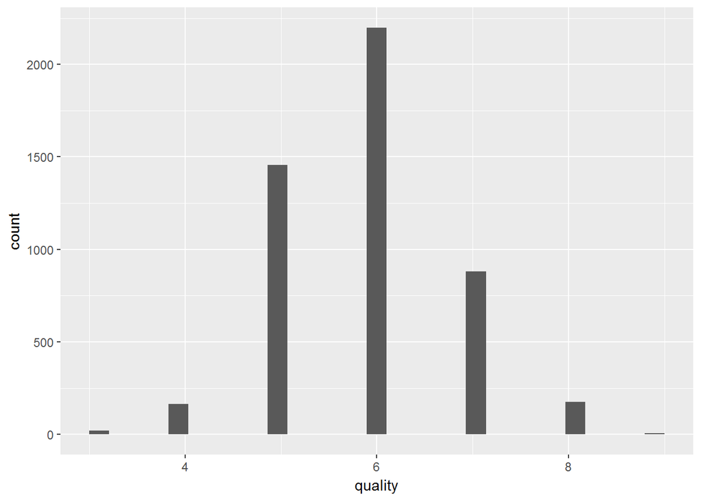

从quality的histogram可以看出虽然quality的评分范围是0-10分，但数据集中的评级分布于3-9分，其中得到6分的最多（2000多支白葡萄酒）。

下面检查重复值：

```
## # A tibble: 1 x 1
##       n
##   <int>
## 1   937
```

```
##        X        fixed.acidity    volatile.acidity  citric.acid
##  Min.   :   1   Min.   : 3.800   Min.   :0.0800   Min.   :0.0000
##  1st Qu.:1171   1st Qu.: 6.300   1st Qu.:0.2100   1st Qu.:0.2700
##  Median :2386   Median : 6.800   Median :0.2600   Median :0.3200
##  Mean   :2415   Mean   : 6.839   Mean   :0.2805   Mean   :0.3343
##  3rd Qu.:3642   3rd Qu.: 7.300   3rd Qu.:0.3300   3rd Qu.:0.3900
##  Max.   :4898   Max.   :14.200   Max.   :1.1000   Max.   :1.6600
##  residual.sugar     chlorides       free.sulfur.dioxide
##  Min.   : 0.600   Min.   :0.00900   Min.   :  2.00
##  1st Qu.: 1.600   1st Qu.:0.03500   1st Qu.: 23.00
##  Median : 4.700   Median :0.04200   Median : 33.00
##  Mean   : 5.915   Mean   :0.04591   Mean   : 34.89
##  3rd Qu.: 8.900   3rd Qu.:0.05000   3rd Qu.: 45.00
##  Max.   :65.800   Max.   :0.34600   Max.   :289.00
##  total.sulfur.dioxide    density             pH          sulphates
##  Min.   :  9.0        Min.   :0.9871   Min.   :2.720   Min.   :0.2200
##  1st Qu.:106.0        1st Qu.:0.9916   1st Qu.:3.090   1st Qu.:0.4100
##  Median :133.0        Median :0.9935   Median :3.180   Median :0.4800
##  Mean   :137.2        Mean   :0.9938   Mean   :3.195   Mean   :0.4904
##  3rd Qu.:166.0        3rd Qu.:0.9957   3rd Qu.:3.290   3rd Qu.:0.5500
##  Max.   :440.0        Max.   :1.0390   Max.   :3.820   Max.   :1.0800
##     alcohol         quality
##  Min.   : 8.00   Min.   :3.000
##  1st Qu.: 9.50   1st Qu.:5.000
##  Median :10.40   Median :6.000
##  Mean   :10.59   Mean   :5.855
##  3rd Qu.:11.40   3rd Qu.:6.000
##  Max.   :14.20   Max.   :9.000
```

该数据集共有937行重复数据，因为相同的指标对应得出了相同的评级，在考虑哪些因数会影响葡萄酒评分时，我们不需要重复的数据行。我们把删除重复行的新数据集命名为wine_clean.

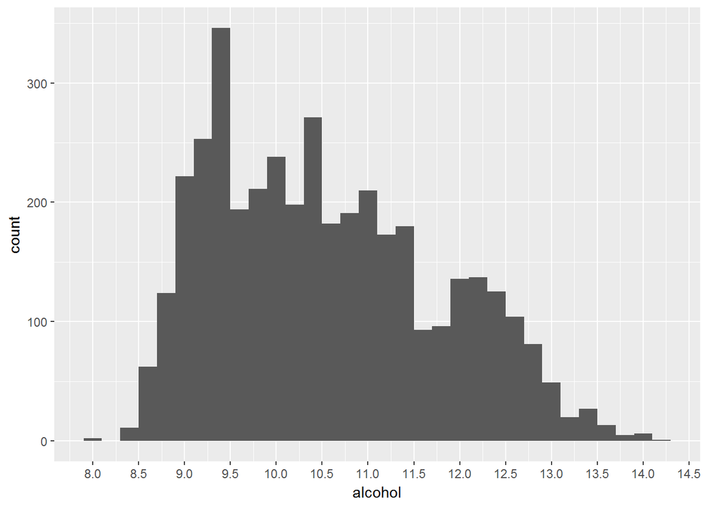

酒精含量呈现右偏态分布，可见大部分白葡萄酒的酒精浓度较低，中值在10.4度。

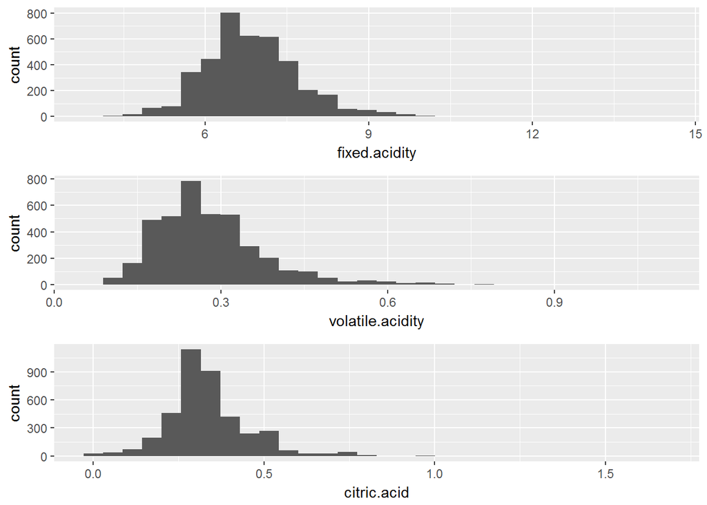

由横坐标可以看出白葡萄酒中以非挥发性酸(fixed acidity)为主，中值为6.8g/dm^3。 挥发性酸（volatile acidity）呈现右偏态，中值为0.26g/dm^3，该指标若太高会有不好的醋味。 柠檬酸（citric acid）则可以增加清新果香，其中值为0.32g/dm^3。

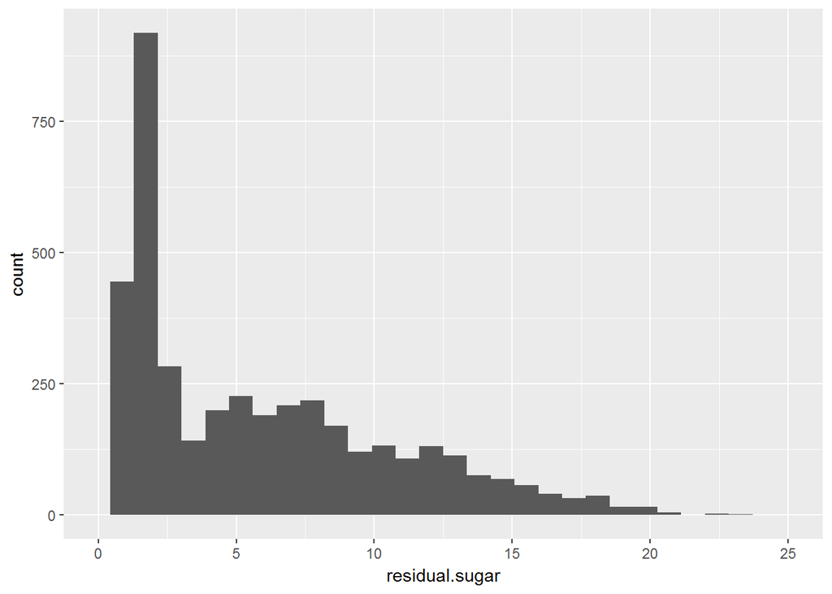

残糖量可见明显的右偏。其中在summary中的最大值为65.8，可能为outlier。根据数据字典，残糖量>45可以视为甜白葡萄酒，下面检查残糖>45的数据：

```
##      X fixed.acidity volatile.acidity citric.acid residual.sugar chlorides
## 1 2782           7.8            0.965         0.6           65.8     0.074
##   free.sulfur.dioxide total.sulfur.dioxide density   pH sulphates alcohol
## 1                   8                  160 1.03898 3.39      0.69    11.7
##   quality
## 1       6
```

因其他值未见明显异常，故保留该数据。残糖量的中值为4.7g/dm^3.

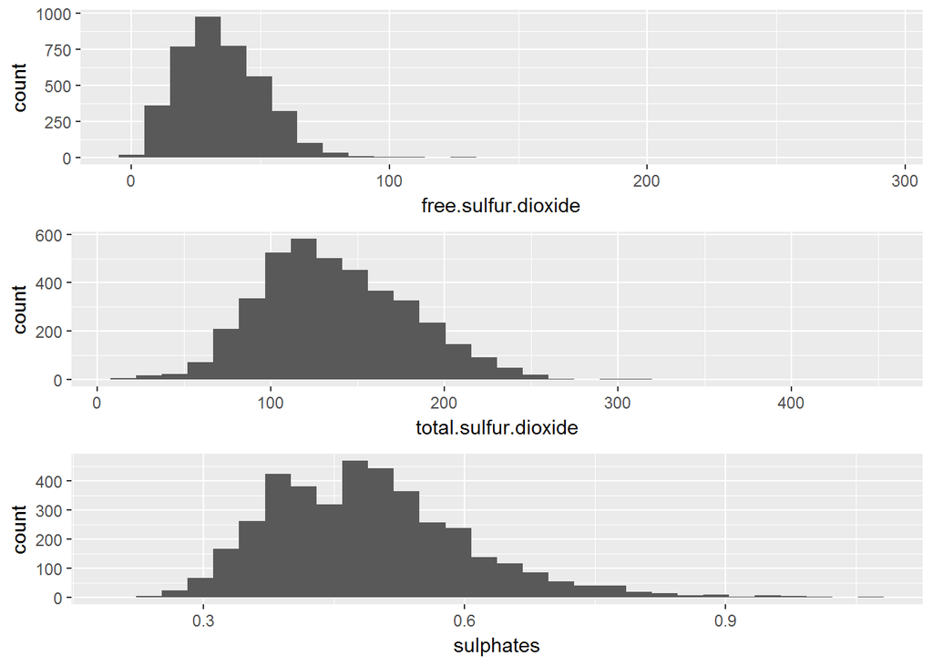

检查free sulfur dioxide的异常值

```
##      X fixed.acidity volatile.acidity citric.acid residual.sugar chlorides
## 1 4746           6.1             0.26        0.25            2.9     0.047
##   free.sulfur.dioxide total.sulfur.dioxide density   pH sulphates alcohol
## 1                 289                  440 0.99314 3.44      0.64    10.5
##   quality
## 1       3
```

因total sulfur dioxide > free sulfur dioxide, 且评分为3分，符合数据字典中对free SO2过高对酒口感的不利影响的说明，故不对该数据做其他处理。

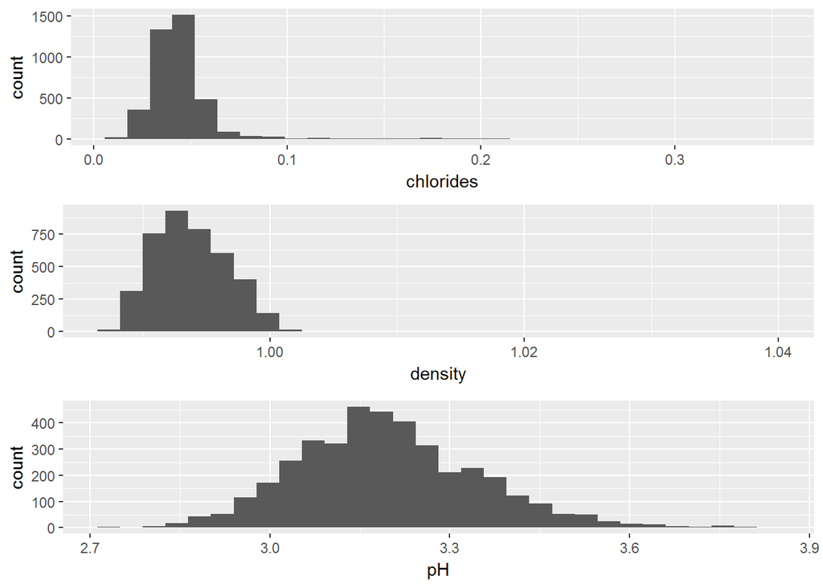

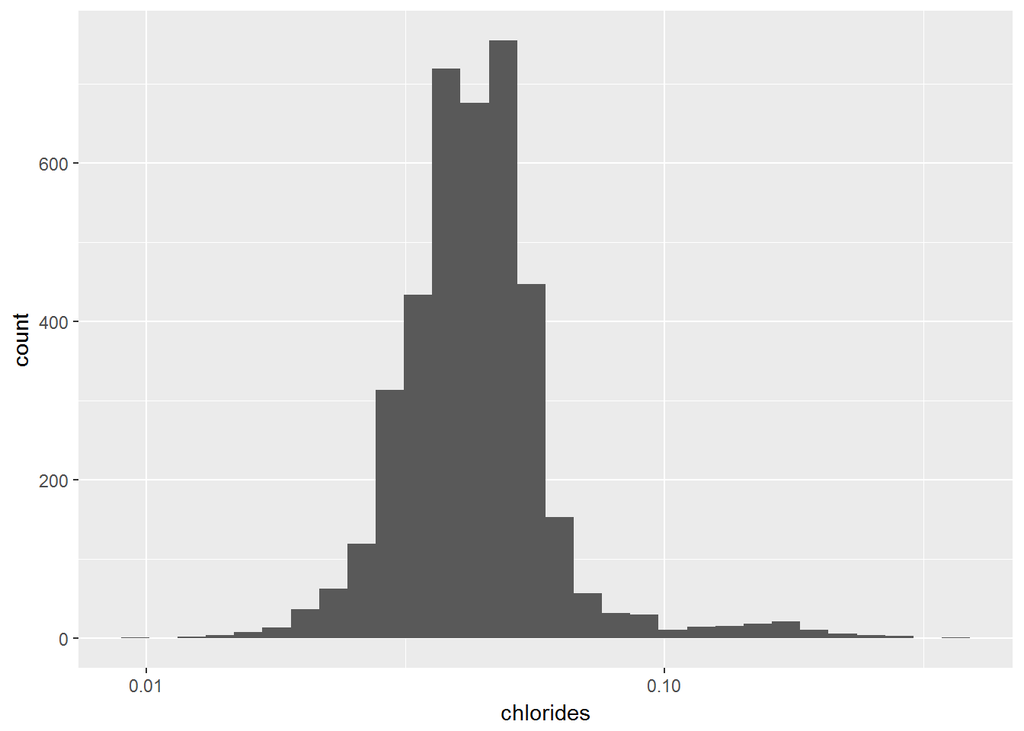

# 单变量分析

### 你的数据集结构是什么？

该数据集包含4898支白葡萄酒样本，每个样本有13个特征(包含序号列X)。

### 你的数据集内感兴趣的主要特性有哪些？

主要考虑各项指标与quality之间的关系。

### 你认为数据集内哪些其他特征可以帮助你探索兴趣特点？

影响气味和口感的因素，比如volatile acidity, citric acid, residual sugar, free sulfur dioxide, sulphates, alcohol.

### 根据数据集内已有变量，你是否创建了任何新变量？

未创建新变量。

### 在已经探究的特性中，是否存在任何异常分布？你是否对数据进行一些操作，如清洁、调整或改变数据的形式？如果是，你为什么会这样做？

在free sulfur dioxide, residual sugar,chlorides中存在异常值，其中前两项未作处理，最后一项转化为对数形式进行了查看。同时发现该数据集中有900多行重复的数据，对重复行进行了删除操作。

# 双变量绘图选择

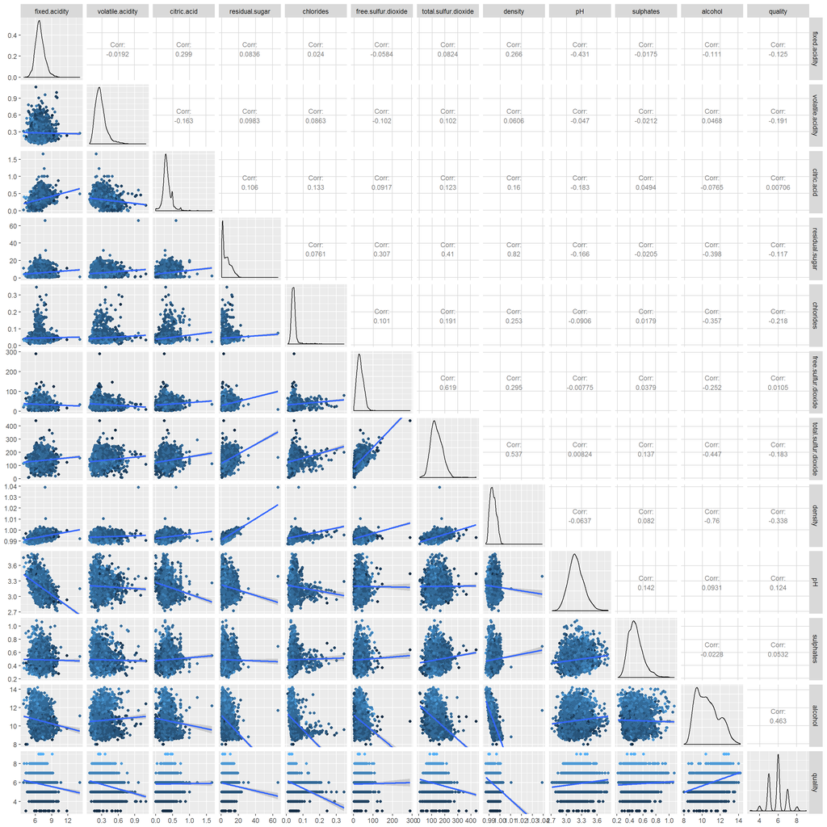

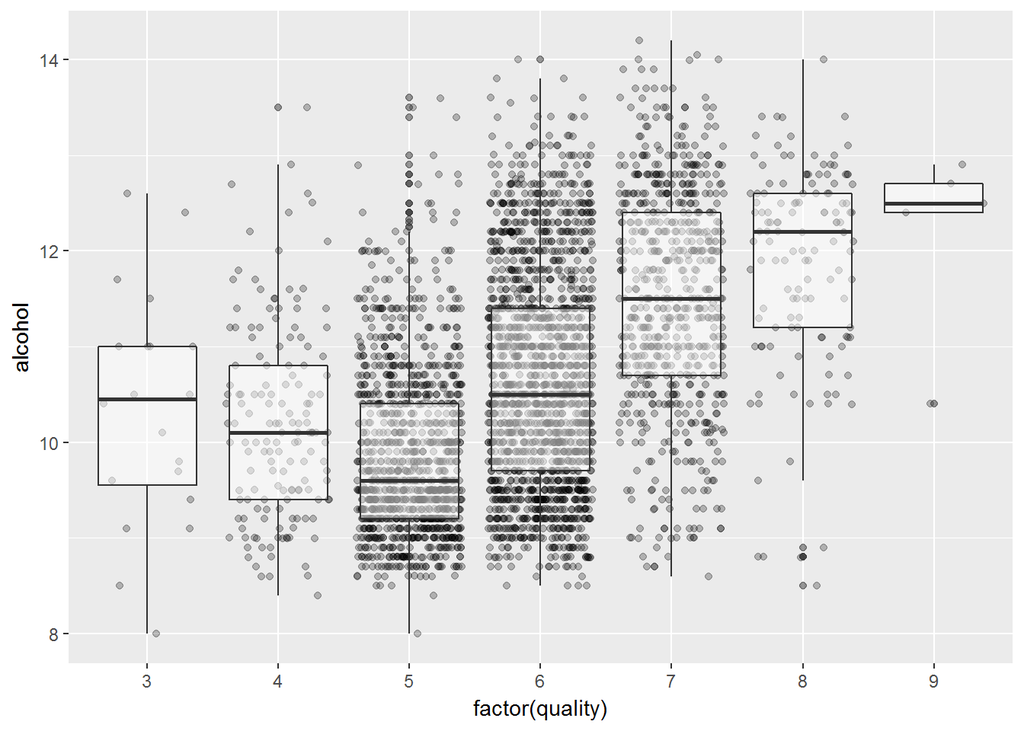

评分高的白葡萄酒大部分酒精浓度也会较高。

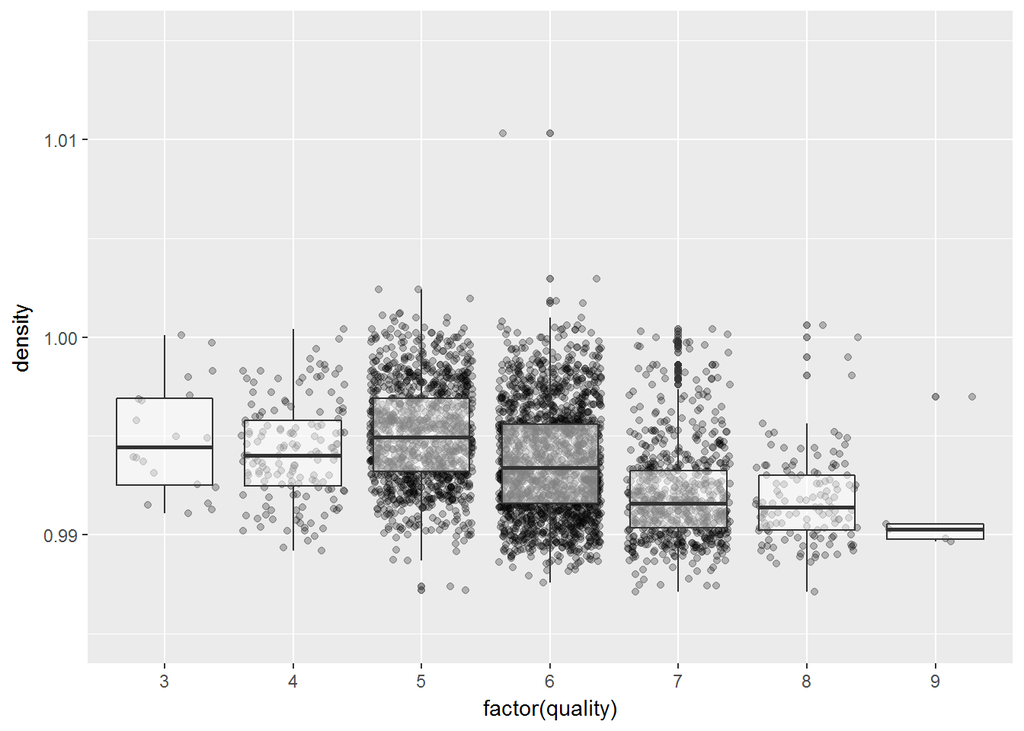

评级越高的酒的density总体越低。

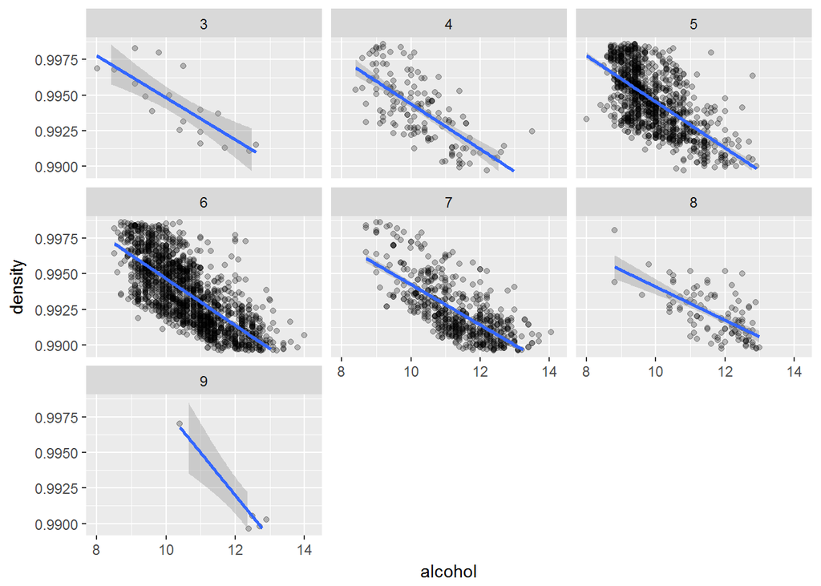

酒精浓度高的酒，density越低，该特点对于任何评级都一致。由常识我们知道酒精的密度低于水，因此酒精浓度高–>density低–>quality高，这三者是相对应的。

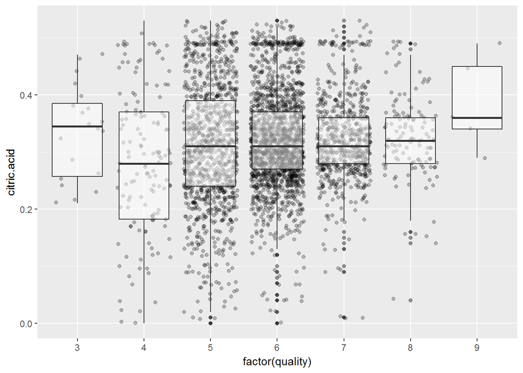

虽然citric acid可以给酒增加freshness，但对评级的影响不大。总体来看，得到最高分9分的酒的citric acid中位数高于其他评分的酒。

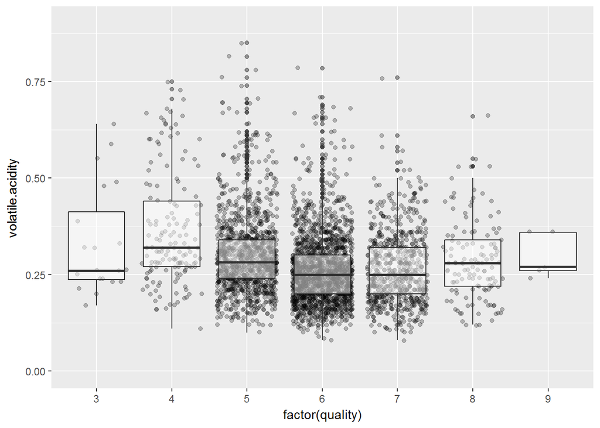

评级更高的酒的挥发性酸volatile acidity浓度略低于评级低的酒,但整体趋势不明显。

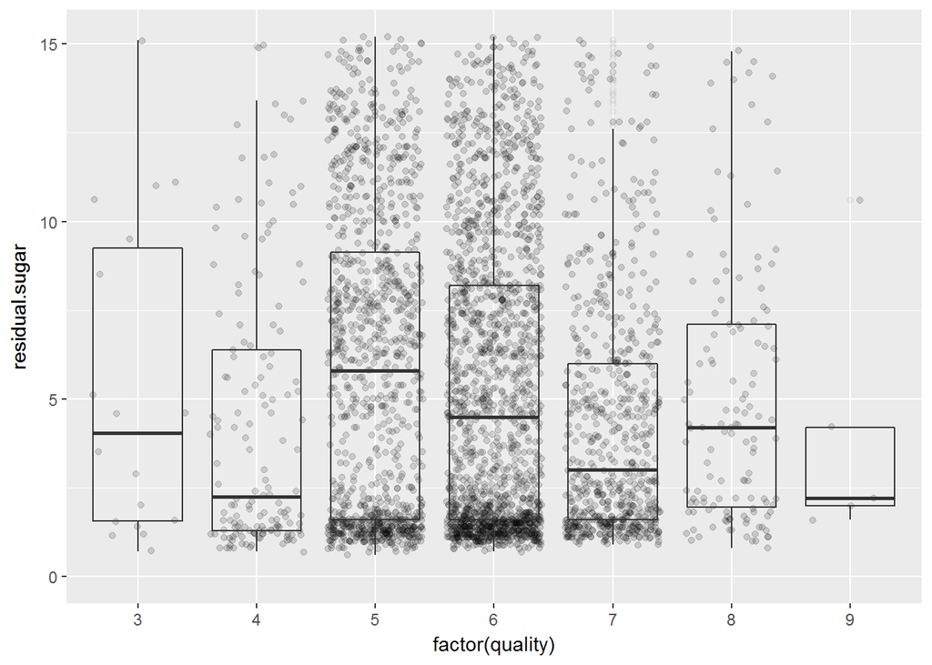

从boxplot来看各个评级的酒的残糖量分布没有明显趋势，从图中仅能看出评级最高的酒的残糖量是较低的。

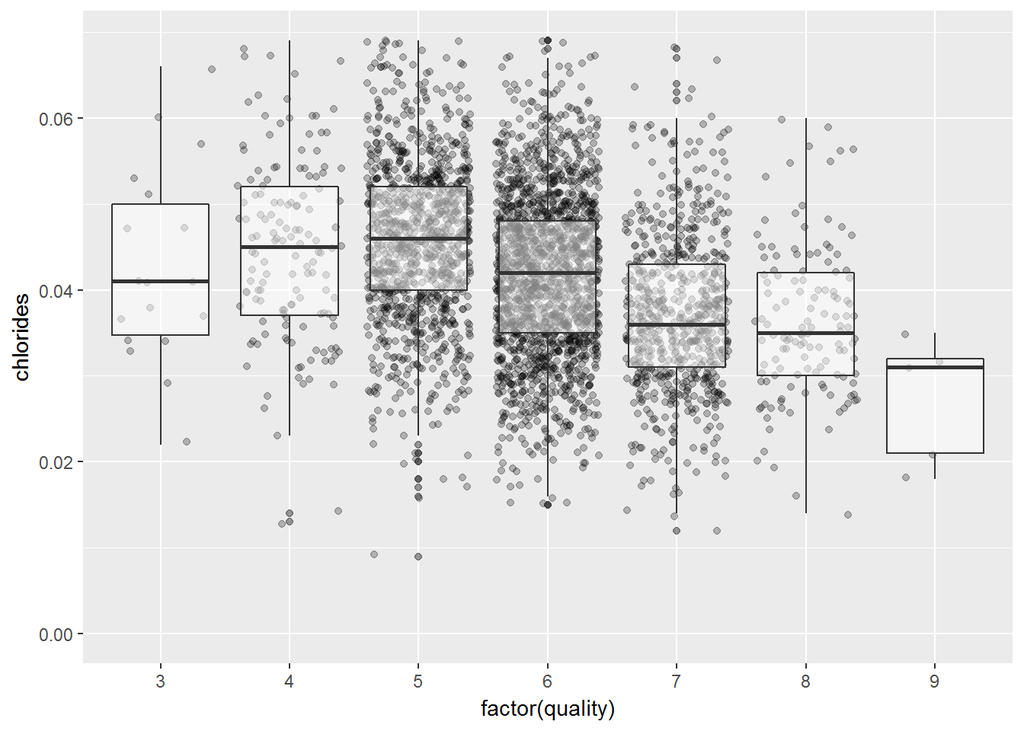

chlorides（盐分）低的酒评级越更高。

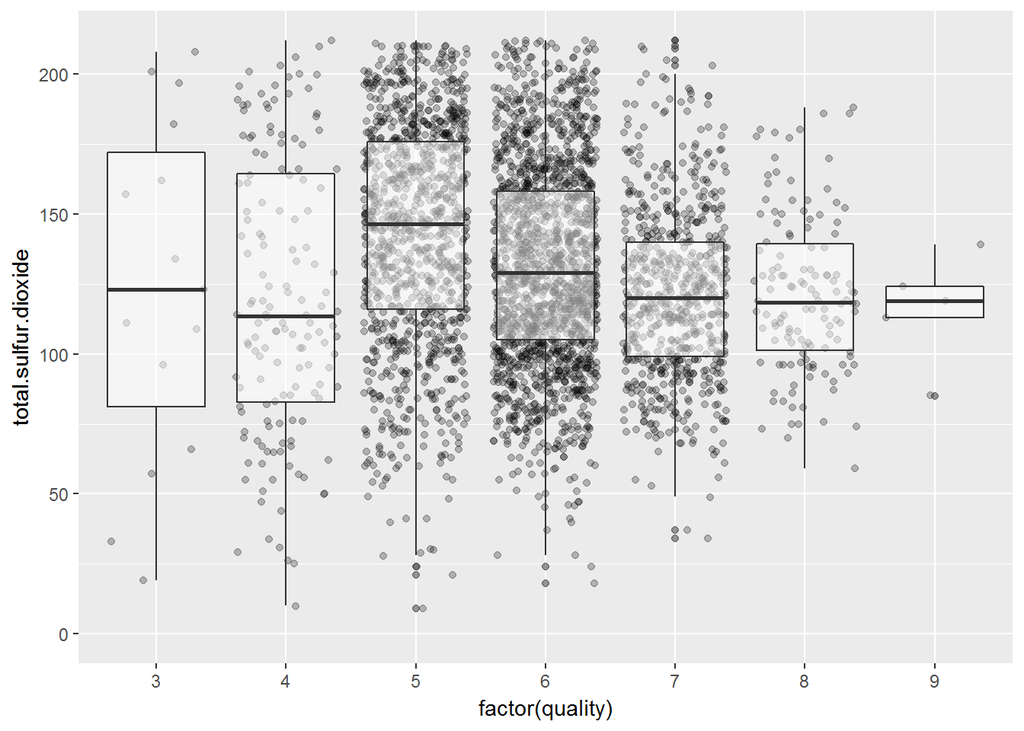

对于得到5分以上的酒来说，总二氧化硫含量低的酒的评级更高。

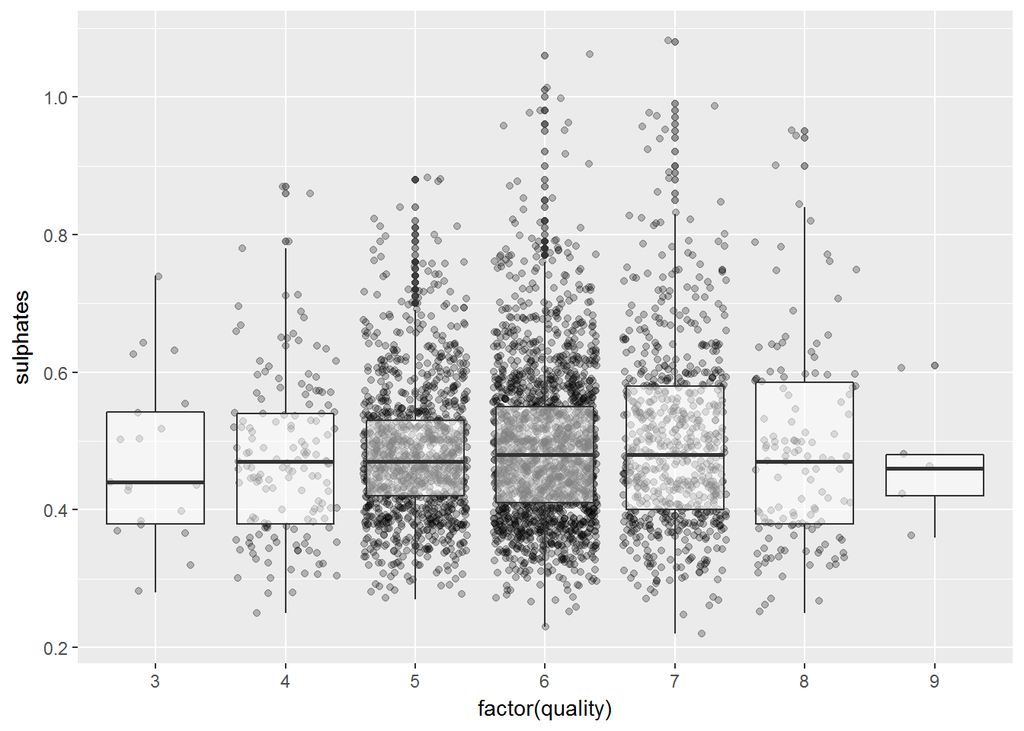

sulphates硫酸盐对quality的影响不明显。

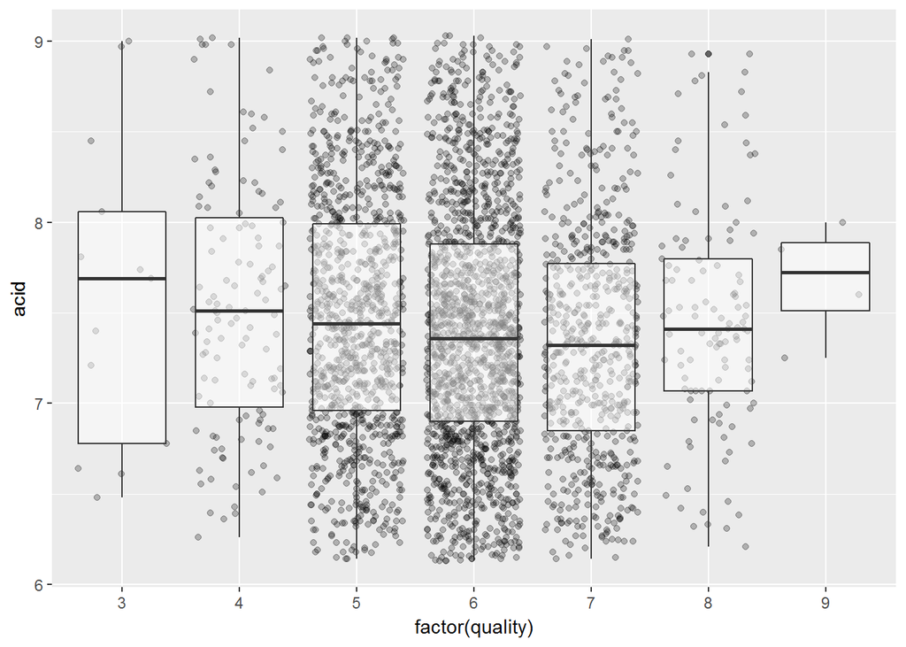

出于好奇，我把所有的酸加总为一列acid，再比较酸度对quality的影响，但没有看到很强的相关性。可能由于volatile acidity和citric acid的含量均很小，与fixed acidity不在一个数量级。

最后，验证PH值越低，酸度越高的常识。

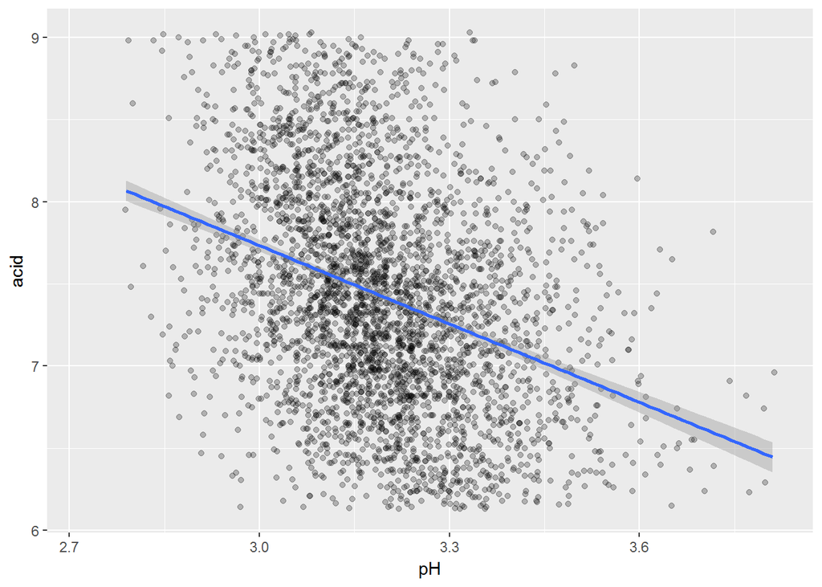

# 双变量分析

### 你是否观察到主要特性与其他特性之间的有趣关系？

density与alcohol呈负相关，与residual sugar呈正相关。 acid酸度水平越高，PH值越低。 residual sugar对quality的影响不如alcohol显著，这一点有些让人意外。

### 你发现最强的关系是什么？

alcohol与quality的正相关性。

# 多变量绘图选择

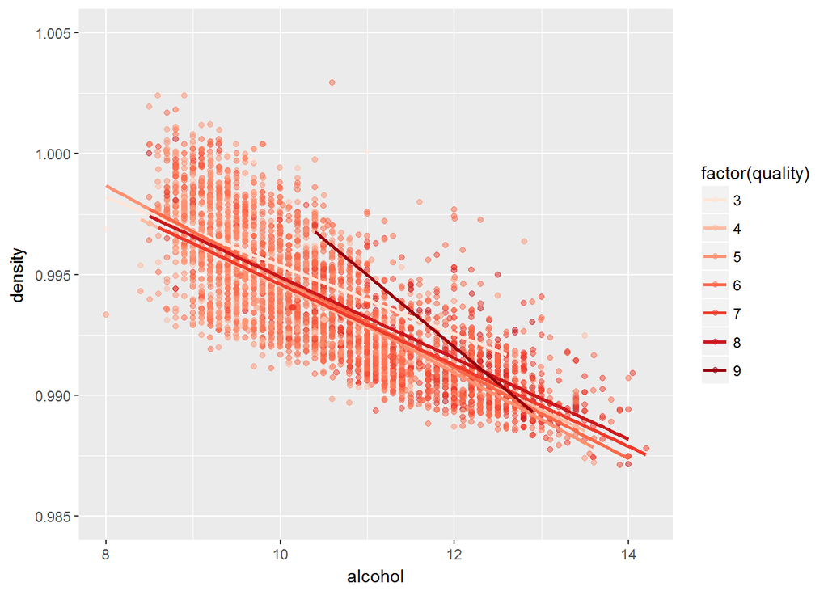

酒精浓度高的酒评级更高，density更低。

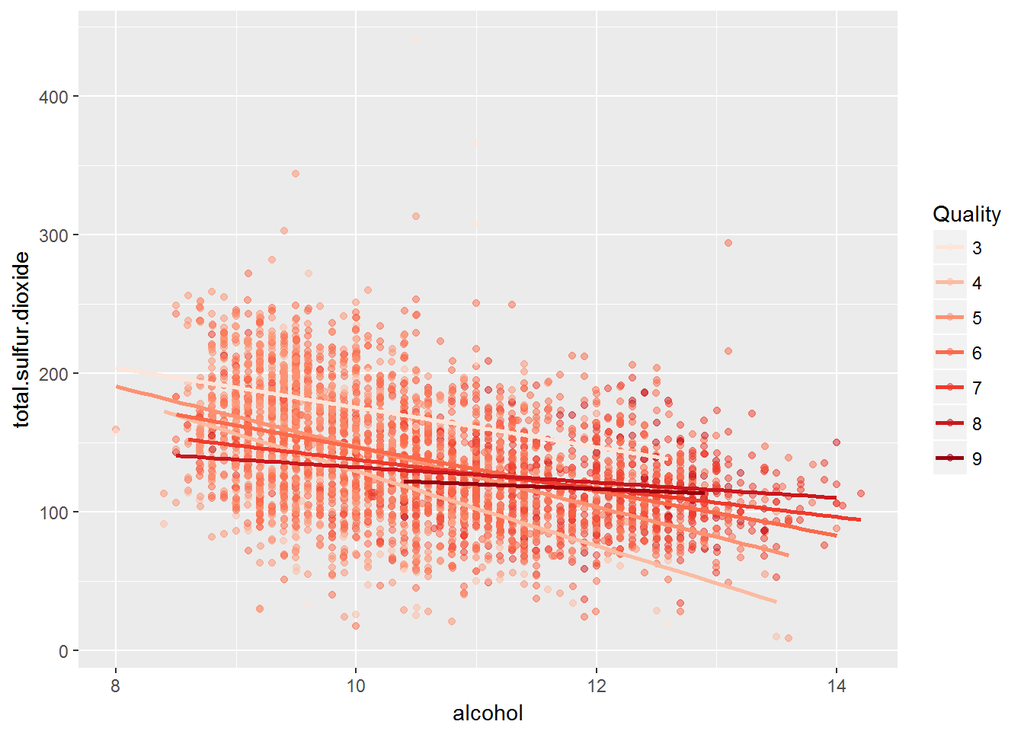

总二氧化硫对quality的影响也不如酒精明显。

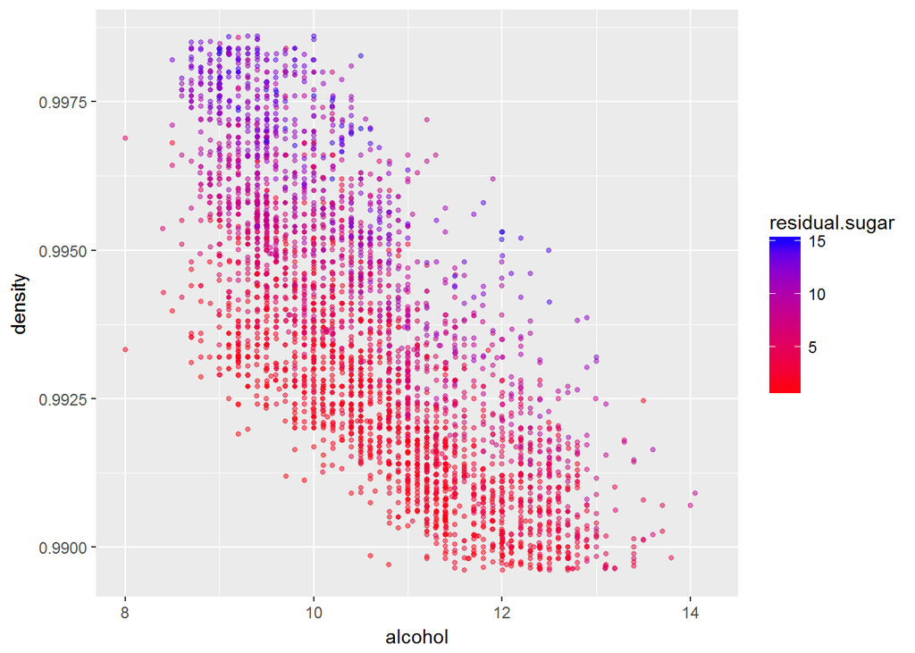

该图可以明确的展现density, alcohol, residual sugar三者的关系： density越大，alcohol越低，residual sugar越高。

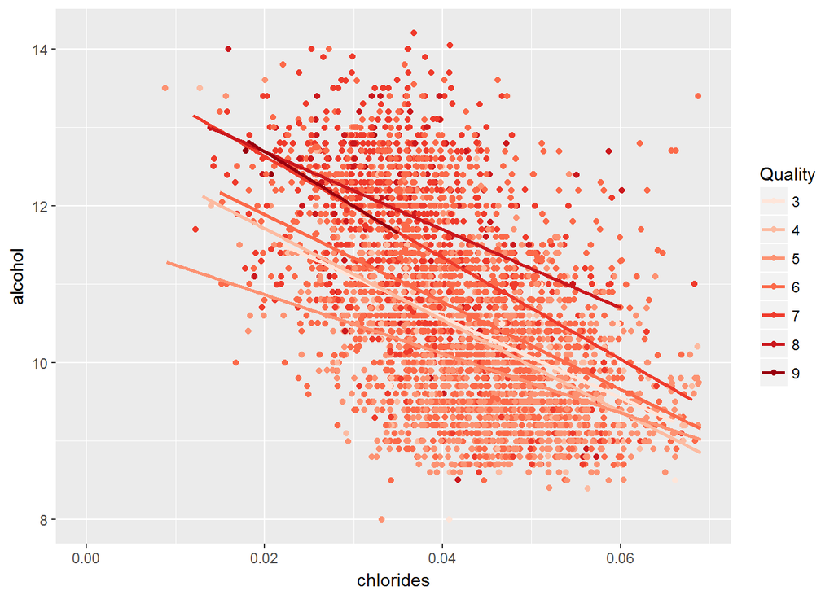

该图可见，chlorides越小，alcohol越大，评级越高。

创建模型：

```
##
## Calls:
## m1: lm(formula = quality ~ alcohol, data = wine_clean)
## m2: lm(formula = quality ~ alcohol + volatile.acidity, data = wine_clean)
## m3: lm(formula = quality ~ alcohol + volatile.acidity + residual.sugar,
##     data = wine_clean)
## m4: lm(formula = quality ~ alcohol + volatile.acidity + residual.sugar +
##     sulphates, data = wine_clean)
## m5: lm(formula = quality ~ alcohol + volatile.acidity + residual.sugar +
##     sulphates + total.sulfur.dioxide, data = wine_clean)
##
## ==============================================================================================
##                              m1            m2            m3            m4            m5
## ----------------------------------------------------------------------------------------------
##   (Intercept)               2.268***      2.705***      2.269***      2.006***      1.900***
##                            (0.110)       (0.110)       (0.124)       (0.136)       (0.154)
##   alcohol                   0.339***      0.346***      0.379***      0.380***      0.386***
##                            (0.010)       (0.010)       (0.011)       (0.011)       (0.012)
##   volatile.acidity                       -1.833***     -1.945***     -1.936***     -1.955***
##                                          (0.118)       (0.118)       (0.118)       (0.119)
##   residual.sugar                                        0.020***      0.021***      0.020***
##                                                        (0.003)       (0.003)       (0.003)
##   sulphates                                                           0.491***      0.466***
##                                                                      (0.106)       (0.108)
##   total.sulfur.dioxide                                                              0.000
##                                                                                    (0.000)
## ----------------------------------------------------------------------------------------------
##   R-squared                 0.214         0.259         0.270         0.274         0.274
##   adj. R-squared            0.214         0.259         0.269         0.273         0.273
##   sigma                     0.790         0.767         0.761         0.760         0.759
##   F                      1079.485       693.297       486.938       372.412       298.463
##   p                         0.000         0.000         0.000         0.000         0.000
##   Log-likelihood        -4683.836     -4566.526     -4539.077     -4528.427     -4527.320
##   Deviance               2468.463      2326.496      2294.474      2282.170      2280.894
##   AIC                    9373.672      9141.051      9088.153      9068.855      9068.640
##   BIC                    9392.524      9166.188      9119.575      9106.560      9112.630
##   N                      3961          3961          3961          3961          3961
## ==============================================================================================
```

# 多变量分析

### 探讨你在这部分探究中观察到的一些关系。通过观察感兴趣的特性，是否存在相互促进的特性？

探索发现大部分指标与alcohol相比，对quality的影响都不够大。其中，alcohol越高，chlorides越小，评级越高。

### 这些特性之间是否存在有趣或惊人的联系呢？

最明显的关联是density, alcohol, residual sugar三者的强相关性： density越大，alcohol越低，residual sugar越高。

### 选项：你是否创建过数据集的任何模型？讨论你模型的优缺点。

把quality作为一个numeric value建立了线性模型。但R-squared仅有0.274，故拟合度不佳。

# 定稿图与总结

### 绘图一

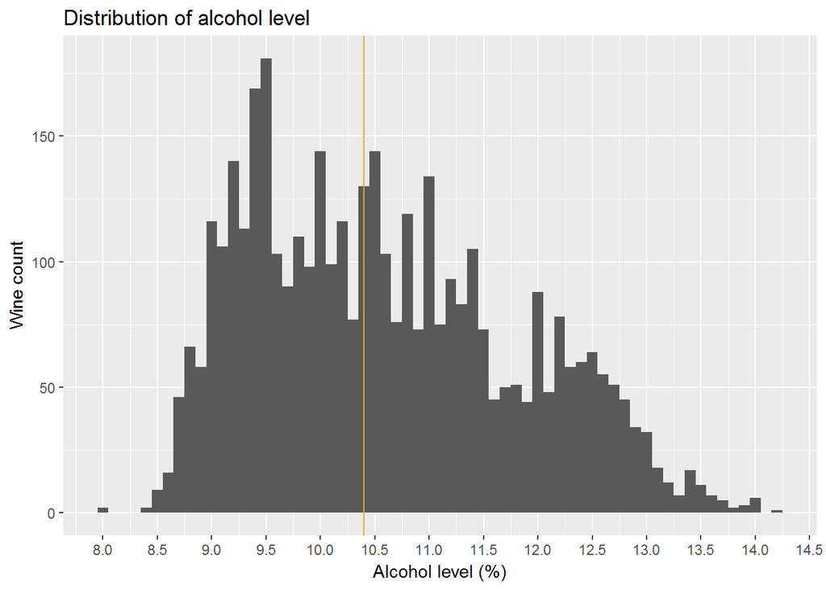

### 描述一

数据集中的样本酒精含量alcohol整体呈右偏态，说明酒精度高的酒在样本中的占比较少。

### 绘图二

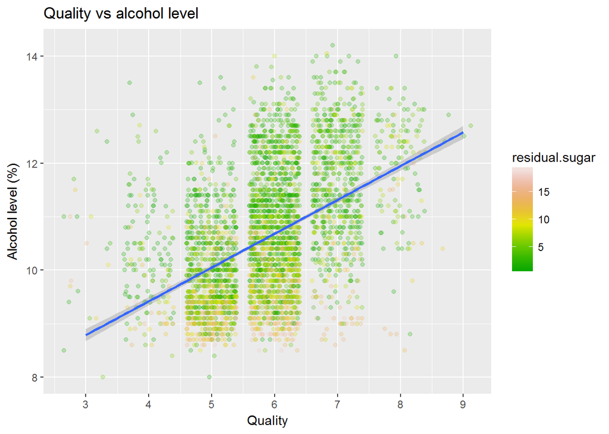

### 描述二

随着酒精浓度的增加，质量等级quality也相应的提高。同时resudial sugar大的酒主要聚集在图片底部，说明残糖量高的白葡萄酒通常酒精含量比较低。

### 绘图三

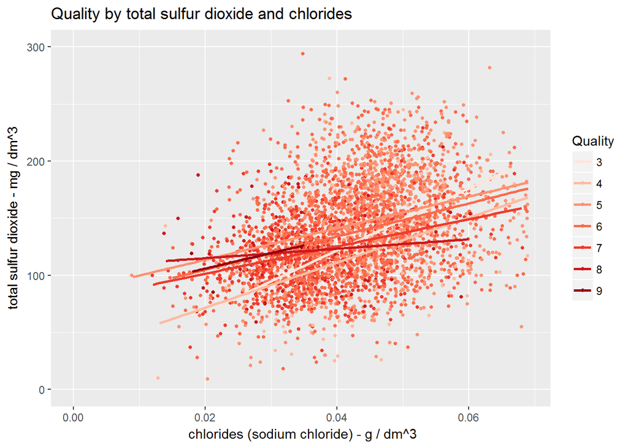

### 描述三

chlorides氯化物含量越低，total sulfur dioxide含量越低，白葡萄酒的质量越高。

# 反思

- 在前面的分析中发现酒精度高的酒的评级更高，但由绘图1发现酒精度高的酒在样本中的占比较少。那么超过14.5度的酒会得到怎样的评分？以及满分10分的酒会有怎样的特征？这两个问题由于样本容量不足，无法得到解答。
- 同时，为数据集创建的模型也没有得到很好的结果。一个原因是样本量不够均衡，我们仅有少量得分3-4分和8-9分的葡萄酒样本，同时缺少得分1-2分以及满分10分的样本。另一个原因是，除去酒精含量与评级表现出比较明显的相关性，其他指标与评级的相关性都较弱。
- 另外，在数据集中最有趣的关系是density, alcohol, 以及residual sugar之间的关系。我们发现density高的酒的酒精含量会比较低，残糖量比较高，意味着酒比较甜而不烈。但另一方面，酒精含量高、density低的酒的评级更高，说明在wine experts看来，清淡的甜白葡萄酒并不能称之为好酒。

### 下一步分析计划：

- 考虑到现有数据集是基于2009年的Portuguese “Vinho Verde” ，我们还可以获取更全面、更新的酒类评分样本，比如从知名的葡萄酒评分网站wine spectator获取数据。
- 由于目前的13个variables并不能得出很好的评分拟合模型，我们可以考虑增加部分特征，比如葡萄酒的产区、年份等。
- 最后，除了白葡萄酒数据集外，我们还有一个包含1599个observation的红葡萄酒数据集，对比“决定两种葡萄酒评级的因素”也会是一项有趣的研究。